# LLM-ek programozott használata kutatási célra

Tamási Árpád · ELTE TáTK

9. óra — 2026. november 23.

# A mai óra

## Egy kérdés tőletek, *és egy háló*, amibe a gép beleír

|  | Perc | Mi |
| --- | --- | --- |
| A | 25 | Topikmodellezés, általánosan: egy kérdés tőletek és egy skillcsomag |
| B | 35 | Weight Space Programming: az eredeti, és kipróbálva a backgammonon |
|  | 10 | Körben: miről szeretnétek még hallani |

# Topikmodellezés, általánosan

## A kérdés: mi lesz a skillel, ha a szónak *más jelentése* van az új korpuszban?

> Mi van akkor, ha a skill olyan nyelvi jellemzőkre épül, amelyek szavainak teljesen más, másodlagos jelentései vannak az új korpuszban?

Kérdés e-mailben, a múlt óra után

- *Paks:* atomerőmű, vagy a Paksi FC
- *hazai:* magyarországi, vagy hazai pályán játszott
- *víz:* vízgazdálkodás, vagy vízisport

## A szólista *a szóalakot* látja, a nyelvi modell *a mondatot*

#### Szólista, topikmodell

- Megszámolja a szavakat, a sorrend és a környezet elvész
- A „paksi” mindig ugyanaz a szó
- Ami a régi korpuszon működött, az a szóalakokon működött

#### Nyelvi modell

- Az egész mondatot olvassa, a szó a környezetéből kap jelentést
- „A paksi csapat hazai pályán kapott ki” → sport
- Hogy Paksnak focicsapata is van, azt eleve tudja; hogy neked melyik számít, azt a skillből

## Amit kutatóként *már tudtok*

- Az új korpusz új kétértelműségeket hoz: előre nem lehet felsorolni őket
- Ezért vak minta kell, a kétértelmű szavakra rásúlyozva
- A szubjektív rész a kódkönyvé: a mérce két kódoló egyezése

## Új topikmodell: *mi mindent* kell csinálni?

| Skill | Mit csinál | Te döntöd el |
| --- | --- | --- |
| **gyűjtés** | szövegek, metaadattal | mi marad bent |
| **előkészítés** | szótövezés, töltelékszavak | mi számít töltelékszónak |
| **modell** | több topikszámmal lefut | hány topik legyen |
| **címkézés** | jellemző szavak, idézetek, névjavaslat | a neveket |
| **validálás** | betolakodó szó, vak minta, újrafuttatás | elég jó-e |

Programozni nem kell: a kódot a Claude írja.

## A nyelvi modell *megkeresi*

- **A kétértelmű szavakat:** *Paks*: atomerőmű vagy focicsapat
- **A szóváltozatokat:** *atomerőmű, atomerőműves, paksi bővítés*: egy fogalom
- **Az átfedéseket:** két topik, ugyanazokkal a szavakkal
- **A réseket:** szövegek, amelyek egyik topikba sem illenek

A topikmodell a szavakat számolja, a nyelvi modell elolvassa, amit talált.

## Kezdőprompt, *OpenSpeccel*

```
/opsx:propose Skillcsomag új topikmodell felállítására és gyors ellenőrzésére:
gyűjtés, előkészítés, modell, címkézés, validálás.
A nyelvi modell keresse meg a kétértelmű szavakat, a szóváltozatokat,
a topikok átfedéseit és a réseket.
A validáláshoz: betolakodó-szó teszt, 30 szöveges vak minta, újrafuttatás.
Minden skill mutassa meg, mit csinált, és a döntést hagyja rám.
```

- A javaslatot, a specifikációt és a feladatlistát te nézed át
- Csak utána: `/opsx:apply`

# Weight Space Programming

## Egy friss kutatás: a nyelvi modell *egy másik MI belsejét* írja

- Ránéz egy másik mesterséges intelligencia belsejére, és megmondja, mire tanították
- Tanítás nélkül megír egy kis játékost, amely legyőzi a hagyományosan tanítottat
- Egy kis nyelvi modell belsejének 0,016%-át átírva a matekteszten 8%-ról 48%-ra javít

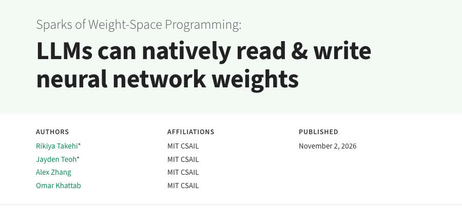

rikiyat.github.io/blog/weight-space-programming

## Kipróbáltam: *a backgammonon*

- Van egy backgammon-programom: a lépésekről egy kis mesterséges intelligencia dönt
- A kérdés: meg tudja-e írni egy nyelvi modell a belsejét, tanítás nélkül?
- És ha igen: jobban játszik-e, és jobban tanul-e tovább?

Ehhez előbb két dolog kell: mi a backgammon, és mi van egy ilyen program belsejében.

## A backgammon versenyfutás, *ütéssel*

- Két kockával dobsz, annyit lépsz előre a bábuiddal
- Az nyer, aki előbb körbeviszi mind a 15 bábuját
- **Magányos bábu:** az ellenfél leütheti, és a bábu elölről indul
- **Két bábu egy mezőn:** védett pont, oda az ellenfél nem léphet

[figure not shown]

A kezdőállás, a kockán 3 és 1.

## Egy döntés: *védett pont*, vagy két magányos bábu

- A dobás: 3 és 1
- **Jó lépés (zöld):** 8-ról és 6-ról is az 5-ös mezőre, védett pont
- **Rossz lépés (piros):** a hátsó kettőt egyesével előre, mindkettő magában áll
- A gép a 36 lehetséges dobásából 33-mal leüti valamelyiket

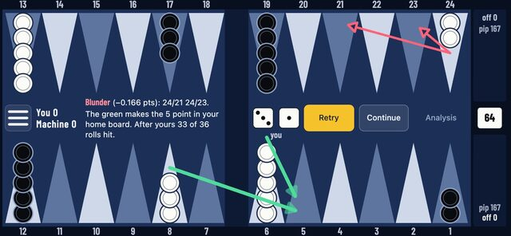

A rossz lépés pirossal, a jó zölddel.

# Neurális háló 101

## Egy utcai lámpa, *kézzel beállítva*

[figure not shown]

## Egy utcai lámpa, *példákból tanítva*

[figure not shown]

## Sok lámpa rétegekben: *ez a neurális háló*

[figure not shown]

Kitalált példa: 196 kitalált égszín, mindegyikhez odaírva, kell-e lámpa.

## 1992: egy háló *önmaga ellen játszva* tanult meg backgammonozni

- TD-Gammon (Gerald Tesauro, IBM): senki nem mondta meg neki, mi a jó lépés, csak azt, ki nyert
- Az első változat csak a táblát látta, és erős középhaladó lett belőle
- A világ legjobbjai közelébe akkor jutott, amikor előrágott fogalmakat is kapott: hány bábu üthető, mennyire zárják el az ellenfél útját
- A lámpánál ez annyi lenne, hogy a háló kész jelet kap: „sötét van”

Ma más út is van: a fogalmakat egy nyelvi modell írja bele *magukba a súlyokba*.

Tesauro, G.: Temporal Difference Learning and TD-Gammon. *Communications of the ACM* 38(3), 1995.

## Ugyanez nagyban: *a backgammon-hálóm*

[figure not shown]

Bemenet: a tábla (52 szám). Kimenet: hat esély — sima, dupla vagy tripla győzelem, mindkét félnek.

Több mint kétmillió súly. Egyiket sem állítja be senki kézzel: a tanítás igazítja őket, játszmáról játszmára.

## Egy betanított háló *így néz ki*

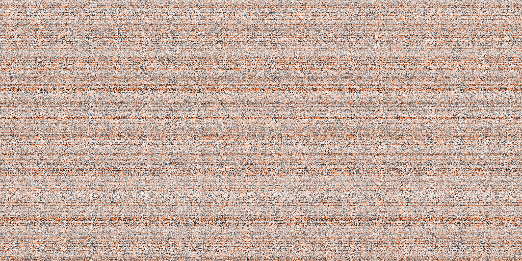

Tisztességesen játszik: döntésenként 19 ezreléket veszít egy erős programhoz képest. Minden számát látjuk, mégsem tudjuk kiolvasni, mit tud.

# Kipróbálva a backgammonon

## Hogyan ír súlyt egy nyelvi modell? *Kódot ír*, ami beállítja őket

- Megkapja a hálót és a leírását: melyik bemenet a tábla melyik mezője
- Programot ír, egységenként: „ez a lámpa akkor égjen, ha egy magányos bábu hat mezőnyire áll az ellenféltől — 36 dobásból 17 leüti”
- A számokat a játék szabályaiból és backgammon-tudásból számolja ki, nem tanulja
- Tanítani nem szabad neki; néhány tucatszor lemérheti, jobban játszik-e a háló

## Weight space programming: *úgy írva, mint a kód*

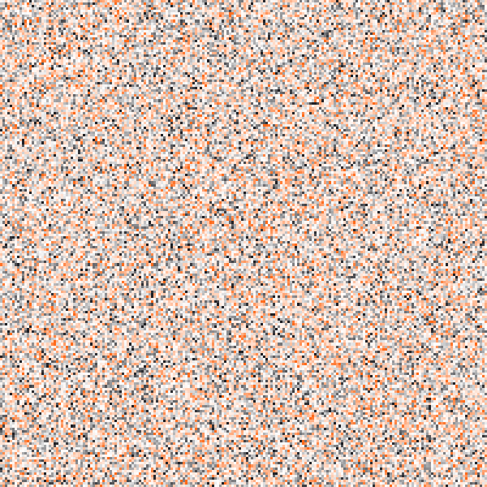

Véletlen kezdés

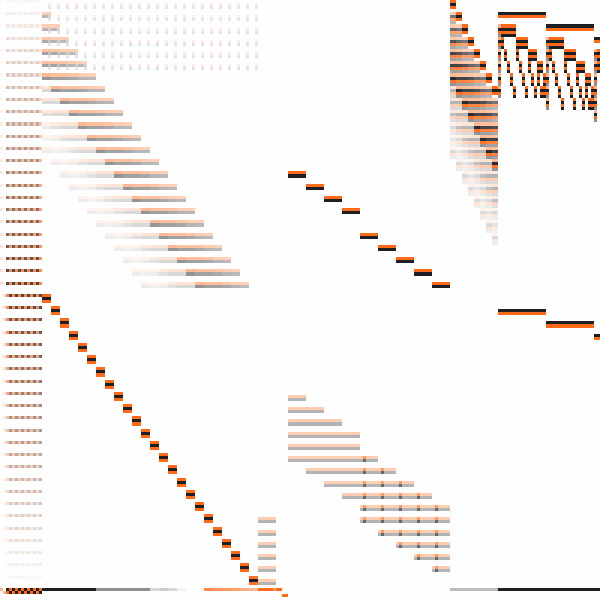

Egy nyelvi modell írta

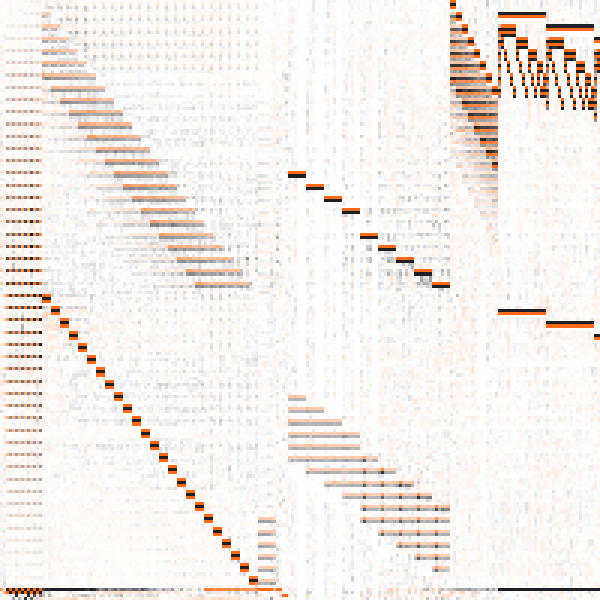

Egymillió játszma után

A beírt minta a tanítás után is megmarad: a tanulás ráépül, nem törli. Hogy hasznos-e, azt a következő dia méri.

Mindhárom kép a backgammon-hálóm második rétegének ugyanaz a sarka (196 × 200 súly). A fogalom: Takehi, Teoh, Zhang, Khattab (MIT CSAIL): „Sparks of Weight-Space Programming”, 2026. nov. 2.

## Tanulás: *előnnyel* indul

Programozott kezdés: 41 ‰-ről indul, 6,0-n áll meg. Véletlen kezdés: 303-ról 19-re jut.

Hiba: átlagos veszteség döntésenként egy erős programhoz képest (‰). Három futásból mindháromban jobb az ember írta fogalmakkal tanított hálónál is (6,7 ‰).

## Egy *betanított* hálóba is bele tud írni

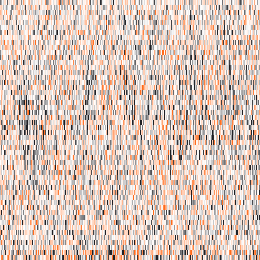

Betanítva: nekünk zaj

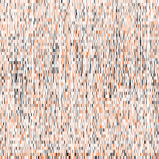

Egy nyelvi modell átírta

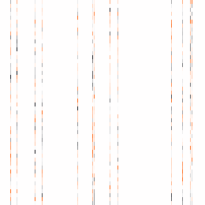

Amit megváltoztatott

Nekünk zaj. A modell megmérte, mely egységeket használja a háló a legkevésbé, és azokba írta a saját fogalmait. A többit békén hagyta.

A háló első rétege (52 × 260, a 2048-ból) 300 ezer játszma után, a Claude Fable átírása előtt és után. Mindhárom kép ugyanazzal a színskálával.

## Átírás: *beesés*, utána tovább tanul

58,6 ‰ → átírva, tanítás nélkül 24,2 → továbbtanítva 14,2 (az átíratlan: 54,7).

Egy futás, egy kezdőérték, kontroll nélkül: ez még nem eredmény, csak ígéret.

## Olvasni is tudja: *mit csinál* egy egység?

- Egy betanított hálóban tíz egység, amelyet senki nem írt: a tanítás alakította őket
- Három nyelvi modell külön-külön megfogalmazta, mit jelez mindegyik
- Ugyanoda jutottak: „versenyelőnyben vagyok”, „az ellenfél hazaért, dupla győzelmem már nem lesz”
- A magyarázatuk más állásokon is előre megmondja, mit csinál az egység

Egy kísérlet a backgammon-hálón, 2026. nov. 22.: Fable, Opus és Astra, utána vitával.

## A háló térképe: *ki mit írt*

[figure not shown]

## A vita: *egymás ellenpéldáiból* javítanak

A 728-as egység: „a leghátsó bábum hazaért, és a verseny még nyitott”

> **Fable:** „Ha túl nagy az előnyöm, már nincs verseny: az egység előbb nő, aztán esik.”

> **Opus:** „Itt tévedtem: a képletem akkor is jutalmazta, hogy otthon vagyok, ha a versenyt már elvesztettem.”

> **Fable:** „Ahol a kollégának volt igaza: az egység 4,3, én 1,8-at jósoltam. Az ő ötletével most 4,1.”

## Kiszámolni egy illesztés is tudja, *megnevezni nem*

- Ha ismered a bemenetet, kiszámolható, mikor kapcsol be egy egység: egy egyszerű illesztés is megmondja
- Egy kis háló illesztése pontosabb is (R² 0,98, a nyelvi modelleké 0,94), de nem mondja meg, *mit jelent*
- Az új: a nyelvi modell **szavakba önti** a számítást, és a játék **ismert fogalmaihoz köti**
- És ellenpéldát szerkeszt rá: ahol a magyarázat nem jön be, ott még nem értjük

Ismerős: ez kódolás, csak nem szövegeken, hanem a háló belsején.

## Játszd ki

arpadtamasi.github.io/backgammon

[figure not shown]

Ezen az oldalon a programozott háló játszik: kipróbálhatod, milyen ellene.

# Hogyan tovább?

## Körben: *miről* szeretnétek még hallani?

- A kérdéseitekből lett ez az óra
- Ami a munkátokban ismétlődik, és szívesen gyorsítanátok rajta
- Ami ma elhangzott, és bővebben kellene

Írjátok meg levélben is, ha most nem jut eszetekbe.